# Introduction to EZFragility package

```r
library(EZFragility)
```

This is the introduction to how to use the EZFragility package. It calculates the neural fragility heatmap based on intracranial electrocorticographic (iEEG) recordings of ictal events. The method is based on the paper by Li et al. (2017) <doi: 10.23919/ACC.2017.7963378>. [Fragility Method](https://ieeexplore.ieee.org/document/7963378)

## Load small ictal ieeg data for patient PT01

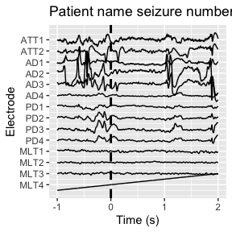

```r
data("pt01Epochm1sp2s")
# seizure onset (soz) electrodes indices
sozIndex <- attr(pt01Epochm1sp2s,"sozIndex")
# seizure onset electrodes names
sozNames <- attr(pt01Epochm1sp2s,"sozZames")

## Visualize ictal data
display <- c(sozIndex,77:80)
timeRange <- c(-1,2)
iEEGplot<-visuIEEGData(ieegts=pt01Epochm1sp2s,timeRange=timeRange,display=display)
iEEGplot
```

## Compute Fragility Matrix

Do not run if you are not ready to wait for >3 minutes. This is the non-optimized sequential version.

```r
window <- 250
step <- 125
lambda <- NULL
nSearch <- 10
pt01Fragm1sp2s <- calcAdjFrag(ieegts = pt01Epochm1sp2s, window = window, step = step, lambda = lambda,nSearch=nSearch)
# Fragility matrix result
pt01Fragm1sp2s$frag[1:5, 1:5]
```

## Plot a heatmap of the Fragility results for patient PT01 for soz electrodes and four non soz electrodes

This plot reproduces Patient 01 results Figure 4 a from Li et al. paper. Time window around seizure onset [-1:2]s - `sozindex` contains the index of the soz electrodes - `77:80` are the index of the non soz electrodes

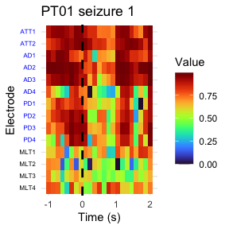

```r
data("pt01Epochm1sp2s")
sozIndex<-attr(pt01Epochm1sp2s,"sozIndex")
data("pt01Fragm1sp2s")
timeRange <- c(-1,2)
display <- c(sozIndex,77:80)
fragplot<-heatmapFrag(frag=pt01Fragm1sp2s,sozID=sozIndex,timeRange = timeRange,title="PT01 seizure 1",display=display)
fragplot
```

## Compute electrodes statistics of fragility map

Compute quantiles, mean and standard deviation for two electrodes group marked as soz non marked as soz

```r
fragstat <- fragStat(frag=pt01Fragm1sp2s, sozID=sozIndex)
fragstat
```

```
#>
#> FragStat object (Summary Statistics by Step)
#> --------------------------------------------------------------
#>  Slot      | Class   | DIM/LEN |  Values
#> --------------------------------------------------------------
#>  qmatrix   | matrix  | [20,23] |  0.6348,  0.6952,  0.7521...
#>  cmeansoz  | numeric | [23]    |  0.7961,  0.7945,  0.8556...
#>  cmeansozc | numeric | [23]    |  0.6964,  0.6475,  0.6907...
#>  csdsoz    | numeric | [23]    |  0.1354,  0.1655,  0.1345...
#>  csdsozc   | numeric | [23]    |  0.1846,  0.1966,  0.1398...
#> --------------------------------------------------------------
#> Use '$attr' to access the data
```

## Plot Fragility distribution

Plot fragility distribution for two electrodes group marked as soz non marked as soz

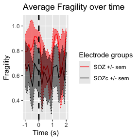

```r
# plot the statistical results
pfragstat<-plotFragDistribution(stat =fragstat,timeRange=timeRange)
pfragstat
```

## Plot fragility quantile

Plot Fragility quantiles for two electrodes group marked as soz non marked as soz

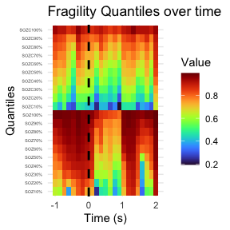

```r
qfragplot<-plotFragQuantile(FragStatObj=fragstat, timeRange=timeRange)
qfragplot
```